# Financial Big Data HW5

109090046

2023-03-27

Given the ‘mpg’ dataset

## Q1.

Select all the numeric variables and calculate the following statistics of each variable: (1) the mean, (2) the maximum, (3) the 25% quantile

```r
data(mpg)

# Select the numeric variables
numeric_vars <- mpg %>% select_if(is.numeric)

# Use summary() and convert it to dataframe
stats <- do.call(cbind, lapply(numeric_vars, summary))

stats[c("Mean", "Max.", "1st Qu."),] %>% ptable()
```

|  | displ | year | cyl | cty | hwy |
| --- | --- | --- | --- | --- | --- |
| Mean | 3.471795 | 2003.5 | 5.888889 | 16.85897 | 23.44017 |
| Max. | 7.000000 | 2008.0 | 8.000000 | 35.00000 | 44.00000 |
| 1st Qu. | 2.400000 | 1999.0 | 4.000000 | 14.00000 | 18.00000 |

## Q2.

Select the ‘hwy’ variable and calculate (1) the 6 summary statistics: Min., 1st Qu., Median, Mean, 3rd Qu., and Max. (2) the value of the 143-th element

```r
stats_hwy <- data.frame(unclass(summary(mpg$hwy)), check.names = FALSE)
colnames(stats_hwy)[1] <- "hwy summary statistics"
stats_hwy %>% ptable()
```

|  | hwy summary statistics |
| --- | --- |
| Min. | 12.00000 |
| 1st Qu. | 18.00000 |
| Median | 24.00000 |
| Mean | 23.44017 |
| 3rd Qu. | 27.00000 |
| Max. | 44.00000 |

```r
cat("the value of the 143-th element is", mpg$hwy[143], "\n")
```

```
the value of the 143-th element is 27
```

## Q3.

Select all the character variables and use the `str_count()` function to calculate the number of character of the longest element of each character variable. (You need to find out how to use the `str_count()` function.)

```r
chr_vars <- mpg %>% select_if(is.character)

library(stringr)
max_lengths <- chr_vars %>% sapply(function(x) max(str_count(x)))

max_lengths %>% ptable()
```

|  | x |
| --- | --- |
| manufacturer | 10 |
| model | 22 |
| trans | 10 |
| drv | 1 |
| fl | 1 |
| class | 10 |

## Q4.

How can we use the `select()` function to obtain the same result as the following command?

```r
mpg %>% relocate(where(is.character)) %>% head() %>% ptable()
```

| manufacturer | model | trans | drv | fl | class | displ | year | cyl | cty | hwy |
| --- | --- | --- | --- | --- | --- | --- | --- | --- | --- | --- |
| audi | a4 | auto(l5) | f | p | compact | 1.8 | 1999 | 4 | 18 | 29 |
| audi | a4 | manual(m5) | f | p | compact | 1.8 | 1999 | 4 | 21 | 29 |
| audi | a4 | manual(m6) | f | p | compact | 2.0 | 2008 | 4 | 20 | 31 |
| audi | a4 | auto(av) | f | p | compact | 2.0 | 2008 | 4 | 21 | 30 |
| audi | a4 | auto(l5) | f | p | compact | 2.8 | 1999 | 6 | 16 | 26 |
| audi | a4 | manual(m5) | f | p | compact | 2.8 | 1999 | 6 | 18 | 26 |

**ANS**

```r
mpg %>% select(where(is.character), everything()) %>% head() %>% ptable()
```

| manufacturer | model | trans | drv | fl | class | displ | year | cyl | cty | hwy |
| --- | --- | --- | --- | --- | --- | --- | --- | --- | --- | --- |
| audi | a4 | auto(l5) | f | p | compact | 1.8 | 1999 | 4 | 18 | 29 |
| audi | a4 | manual(m5) | f | p | compact | 1.8 | 1999 | 4 | 21 | 29 |
| audi | a4 | manual(m6) | f | p | compact | 2.0 | 2008 | 4 | 20 | 31 |
| audi | a4 | auto(av) | f | p | compact | 2.0 | 2008 | 4 | 21 | 30 |
| audi | a4 | auto(l5) | f | p | compact | 2.8 | 1999 | 6 | 16 | 26 |
| audi | a4 | manual(m5) | f | p | compact | 2.8 | 1999 | 6 | 18 | 26 |

What function should we use to replace the ‘…’ part in the following command to get the same result as in the previous command?

```r
mpg %>% relocate(-where(is.numeric)) %>% head() %>% ptable()
```

| manufacturer | model | trans | drv | fl | class | displ | year | cyl | cty | hwy |
| --- | --- | --- | --- | --- | --- | --- | --- | --- | --- | --- |
| audi | a4 | auto(l5) | f | p | compact | 1.8 | 1999 | 4 | 18 | 29 |
| audi | a4 | manual(m5) | f | p | compact | 1.8 | 1999 | 4 | 21 | 29 |
| audi | a4 | manual(m6) | f | p | compact | 2.0 | 2008 | 4 | 20 | 31 |
| audi | a4 | auto(av) | f | p | compact | 2.0 | 2008 | 4 | 21 | 30 |
| audi | a4 | auto(l5) | f | p | compact | 2.8 | 1999 | 6 | 16 | 26 |
| audi | a4 | manual(m5) | f | p | compact | 2.8 | 1999 | 6 | 18 | 26 |

## Q5.

Given `a = mpg %>% slice(1:20)`.

```r
a = mpg %>% slice(1:20)
a %>% ptable()
```

| manufacturer | model | displ | year | cyl | trans | drv | cty | hwy | fl | class |
| --- | --- | --- | --- | --- | --- | --- | --- | --- | --- | --- |
| audi | a4 | 1.8 | 1999 | 4 | auto(l5) | f | 18 | 29 | p | compact |
| audi | a4 | 1.8 | 1999 | 4 | manual(m5) | f | 21 | 29 | p | compact |
| audi | a4 | 2.0 | 2008 | 4 | manual(m6) | f | 20 | 31 | p | compact |
| audi | a4 | 2.0 | 2008 | 4 | auto(av) | f | 21 | 30 | p | compact |
| audi | a4 | 2.8 | 1999 | 6 | auto(l5) | f | 16 | 26 | p | compact |
| audi | a4 | 2.8 | 1999 | 6 | manual(m5) | f | 18 | 26 | p | compact |
| audi | a4 | 3.1 | 2008 | 6 | auto(av) | f | 18 | 27 | p | compact |
| audi | a4 quattro | 1.8 | 1999 | 4 | manual(m5) | 4 | 18 | 26 | p | compact |
| audi | a4 quattro | 1.8 | 1999 | 4 | auto(l5) | 4 | 16 | 25 | p | compact |
| audi | a4 quattro | 2.0 | 2008 | 4 | manual(m6) | 4 | 20 | 28 | p | compact |
| audi | a4 quattro | 2.0 | 2008 | 4 | auto(s6) | 4 | 19 | 27 | p | compact |
| audi | a4 quattro | 2.8 | 1999 | 6 | auto(l5) | 4 | 15 | 25 | p | compact |
| audi | a4 quattro | 2.8 | 1999 | 6 | manual(m5) | 4 | 17 | 25 | p | compact |
| audi | a4 quattro | 3.1 | 2008 | 6 | auto(s6) | 4 | 17 | 25 | p | compact |
| audi | a4 quattro | 3.1 | 2008 | 6 | manual(m6) | 4 | 15 | 25 | p | compact |
| audi | a6 quattro | 2.8 | 1999 | 6 | auto(l5) | 4 | 15 | 24 | p | midsize |
| audi | a6 quattro | 3.1 | 2008 | 6 | auto(s6) | 4 | 17 | 25 | p | midsize |
| audi | a6 quattro | 4.2 | 2008 | 8 | auto(s6) | 4 | 16 | 23 | p | midsize |
| chevrolet | c1500 suburban 2wd | 5.3 | 2008 | 8 | auto(l4) | r | 14 | 20 | r | suv |
| chevrolet | c1500 suburban 2wd | 5.3 | 2008 | 8 | auto(l4) | r | 11 | 15 | e | suv |

Please use the `slice()` function to move the last rows of `a` to the front?

```r
a %>% slice(n(), 1:(n()-1)) %>% ptable()
```

| manufacturer | model | displ | year | cyl | trans | drv | cty | hwy | fl | class |
| --- | --- | --- | --- | --- | --- | --- | --- | --- | --- | --- |
| chevrolet | c1500 suburban 2wd | 5.3 | 2008 | 8 | auto(l4) | r | 11 | 15 | e | suv |
| audi | a4 | 1.8 | 1999 | 4 | auto(l5) | f | 18 | 29 | p | compact |
| audi | a4 | 1.8 | 1999 | 4 | manual(m5) | f | 21 | 29 | p | compact |
| audi | a4 | 2.0 | 2008 | 4 | manual(m6) | f | 20 | 31 | p | compact |
| audi | a4 | 2.0 | 2008 | 4 | auto(av) | f | 21 | 30 | p | compact |
| audi | a4 | 2.8 | 1999 | 6 | auto(l5) | f | 16 | 26 | p | compact |
| audi | a4 | 2.8 | 1999 | 6 | manual(m5) | f | 18 | 26 | p | compact |
| audi | a4 | 3.1 | 2008 | 6 | auto(av) | f | 18 | 27 | p | compact |
| audi | a4 quattro | 1.8 | 1999 | 4 | manual(m5) | 4 | 18 | 26 | p | compact |
| audi | a4 quattro | 1.8 | 1999 | 4 | auto(l5) | 4 | 16 | 25 | p | compact |
| audi | a4 quattro | 2.0 | 2008 | 4 | manual(m6) | 4 | 20 | 28 | p | compact |
| audi | a4 quattro | 2.0 | 2008 | 4 | auto(s6) | 4 | 19 | 27 | p | compact |
| audi | a4 quattro | 2.8 | 1999 | 6 | auto(l5) | 4 | 15 | 25 | p | compact |
| audi | a4 quattro | 2.8 | 1999 | 6 | manual(m5) | 4 | 17 | 25 | p | compact |
| audi | a4 quattro | 3.1 | 2008 | 6 | auto(s6) | 4 | 17 | 25 | p | compact |
| audi | a4 quattro | 3.1 | 2008 | 6 | manual(m6) | 4 | 15 | 25 | p | compact |
| audi | a6 quattro | 2.8 | 1999 | 6 | auto(l5) | 4 | 15 | 24 | p | midsize |
| audi | a6 quattro | 3.1 | 2008 | 6 | auto(s6) | 4 | 17 | 25 | p | midsize |
| audi | a6 quattro | 4.2 | 2008 | 8 | auto(s6) | 4 | 16 | 23 | p | midsize |
| chevrolet | c1500 suburban 2wd | 5.3 | 2008 | 8 | auto(l4) | r | 14 | 20 | r | suv |

Please use the `slice()` function to move all the rows with even row numbers of `a` to the front?

```r
a %>% slice(c(seq(2, n(), by = 2), seq(1, n(), by = 2))) %>% ptable()
```

| manufacturer | model | displ | year | cyl | trans | drv | cty | hwy | fl | class |
| --- | --- | --- | --- | --- | --- | --- | --- | --- | --- | --- |
| audi | a4 | 1.8 | 1999 | 4 | manual(m5) | f | 21 | 29 | p | compact |
| audi | a4 | 2.0 | 2008 | 4 | auto(av) | f | 21 | 30 | p | compact |
| audi | a4 | 2.8 | 1999 | 6 | manual(m5) | f | 18 | 26 | p | compact |
| audi | a4 quattro | 1.8 | 1999 | 4 | manual(m5) | 4 | 18 | 26 | p | compact |
| audi | a4 quattro | 2.0 | 2008 | 4 | manual(m6) | 4 | 20 | 28 | p | compact |
| audi | a4 quattro | 2.8 | 1999 | 6 | auto(l5) | 4 | 15 | 25 | p | compact |
| audi | a4 quattro | 3.1 | 2008 | 6 | auto(s6) | 4 | 17 | 25 | p | compact |
| audi | a6 quattro | 2.8 | 1999 | 6 | auto(l5) | 4 | 15 | 24 | p | midsize |
| audi | a6 quattro | 4.2 | 2008 | 8 | auto(s6) | 4 | 16 | 23 | p | midsize |
| chevrolet | c1500 suburban 2wd | 5.3 | 2008 | 8 | auto(l4) | r | 11 | 15 | e | suv |
| audi | a4 | 1.8 | 1999 | 4 | auto(l5) | f | 18 | 29 | p | compact |
| audi | a4 | 2.0 | 2008 | 4 | manual(m6) | f | 20 | 31 | p | compact |
| audi | a4 | 2.8 | 1999 | 6 | auto(l5) | f | 16 | 26 | p | compact |
| audi | a4 | 3.1 | 2008 | 6 | auto(av) | f | 18 | 27 | p | compact |
| audi | a4 quattro | 1.8 | 1999 | 4 | auto(l5) | 4 | 16 | 25 | p | compact |
| audi | a4 quattro | 2.0 | 2008 | 4 | auto(s6) | 4 | 19 | 27 | p | compact |
| audi | a4 quattro | 2.8 | 1999 | 6 | manual(m5) | 4 | 17 | 25 | p | compact |
| audi | a4 quattro | 3.1 | 2008 | 6 | manual(m6) | 4 | 15 | 25 | p | compact |
| audi | a6 quattro | 3.1 | 2008 | 6 | auto(s6) | 4 | 17 | 25 | p | midsize |
| chevrolet | c1500 suburban 2wd | 5.3 | 2008 | 8 | auto(l4) | r | 14 | 20 | r | suv |

Please use brackets `[]` to redo these two exercise.

```r
# move the last rows of `a` to the front
a[c(nrow(a), 1:(nrow(a)-1)), ] %>% ptable()
```

| manufacturer | model | displ | year | cyl | trans | drv | cty | hwy | fl | class |
| --- | --- | --- | --- | --- | --- | --- | --- | --- | --- | --- |
| chevrolet | c1500 suburban 2wd | 5.3 | 2008 | 8 | auto(l4) | r | 11 | 15 | e | suv |
| audi | a4 | 1.8 | 1999 | 4 | auto(l5) | f | 18 | 29 | p | compact |
| audi | a4 | 1.8 | 1999 | 4 | manual(m5) | f | 21 | 29 | p | compact |
| audi | a4 | 2.0 | 2008 | 4 | manual(m6) | f | 20 | 31 | p | compact |
| audi | a4 | 2.0 | 2008 | 4 | auto(av) | f | 21 | 30 | p | compact |
| audi | a4 | 2.8 | 1999 | 6 | auto(l5) | f | 16 | 26 | p | compact |
| audi | a4 | 2.8 | 1999 | 6 | manual(m5) | f | 18 | 26 | p | compact |
| audi | a4 | 3.1 | 2008 | 6 | auto(av) | f | 18 | 27 | p | compact |
| audi | a4 quattro | 1.8 | 1999 | 4 | manual(m5) | 4 | 18 | 26 | p | compact |
| audi | a4 quattro | 1.8 | 1999 | 4 | auto(l5) | 4 | 16 | 25 | p | compact |
| audi | a4 quattro | 2.0 | 2008 | 4 | manual(m6) | 4 | 20 | 28 | p | compact |
| audi | a4 quattro | 2.0 | 2008 | 4 | auto(s6) | 4 | 19 | 27 | p | compact |
| audi | a4 quattro | 2.8 | 1999 | 6 | auto(l5) | 4 | 15 | 25 | p | compact |
| audi | a4 quattro | 2.8 | 1999 | 6 | manual(m5) | 4 | 17 | 25 | p | compact |
| audi | a4 quattro | 3.1 | 2008 | 6 | auto(s6) | 4 | 17 | 25 | p | compact |
| audi | a4 quattro | 3.1 | 2008 | 6 | manual(m6) | 4 | 15 | 25 | p | compact |
| audi | a6 quattro | 2.8 | 1999 | 6 | auto(l5) | 4 | 15 | 24 | p | midsize |
| audi | a6 quattro | 3.1 | 2008 | 6 | auto(s6) | 4 | 17 | 25 | p | midsize |
| audi | a6 quattro | 4.2 | 2008 | 8 | auto(s6) | 4 | 16 | 23 | p | midsize |
| chevrolet | c1500 suburban 2wd | 5.3 | 2008 | 8 | auto(l4) | r | 14 | 20 | r | suv |

```r
# move all the rows with even row numbers of `a` to the front?
a[c(seq(2, nrow(a), by = 2), seq(1, nrow(a), by = 2)), ] %>% ptable()
```

| manufacturer | model | displ | year | cyl | trans | drv | cty | hwy | fl | class |
| --- | --- | --- | --- | --- | --- | --- | --- | --- | --- | --- |
| audi | a4 | 1.8 | 1999 | 4 | manual(m5) | f | 21 | 29 | p | compact |
| audi | a4 | 2.0 | 2008 | 4 | auto(av) | f | 21 | 30 | p | compact |
| audi | a4 | 2.8 | 1999 | 6 | manual(m5) | f | 18 | 26 | p | compact |
| audi | a4 quattro | 1.8 | 1999 | 4 | manual(m5) | 4 | 18 | 26 | p | compact |
| audi | a4 quattro | 2.0 | 2008 | 4 | manual(m6) | 4 | 20 | 28 | p | compact |
| audi | a4 quattro | 2.8 | 1999 | 6 | auto(l5) | 4 | 15 | 25 | p | compact |
| audi | a4 quattro | 3.1 | 2008 | 6 | auto(s6) | 4 | 17 | 25 | p | compact |
| audi | a6 quattro | 2.8 | 1999 | 6 | auto(l5) | 4 | 15 | 24 | p | midsize |
| audi | a6 quattro | 4.2 | 2008 | 8 | auto(s6) | 4 | 16 | 23 | p | midsize |
| chevrolet | c1500 suburban 2wd | 5.3 | 2008 | 8 | auto(l4) | r | 11 | 15 | e | suv |
| audi | a4 | 1.8 | 1999 | 4 | auto(l5) | f | 18 | 29 | p | compact |
| audi | a4 | 2.0 | 2008 | 4 | manual(m6) | f | 20 | 31 | p | compact |
| audi | a4 | 2.8 | 1999 | 6 | auto(l5) | f | 16 | 26 | p | compact |
| audi | a4 | 3.1 | 2008 | 6 | auto(av) | f | 18 | 27 | p | compact |
| audi | a4 quattro | 1.8 | 1999 | 4 | auto(l5) | 4 | 16 | 25 | p | compact |
| audi | a4 quattro | 2.0 | 2008 | 4 | auto(s6) | 4 | 19 | 27 | p | compact |
| audi | a4 quattro | 2.8 | 1999 | 6 | manual(m5) | 4 | 17 | 25 | p | compact |
| audi | a4 quattro | 3.1 | 2008 | 6 | manual(m6) | 4 | 15 | 25 | p | compact |
| audi | a6 quattro | 3.1 | 2008 | 6 | auto(s6) | 4 | 17 | 25 | p | midsize |
| chevrolet | c1500 suburban 2wd | 5.3 | 2008 | 8 | auto(l4) | r | 14 | 20 | r | suv |

Again please use the ‘subset()’ function to redo these two exercise.

```r
# move the last rows of `a` to the front
rbind(subset(a, row.names(a) == nrow(a)), subset(a, row.names(a) != nrow(a))) %>% ptable()
```

| manufacturer | model | displ | year | cyl | trans | drv | cty | hwy | fl | class |
| --- | --- | --- | --- | --- | --- | --- | --- | --- | --- | --- |
| chevrolet | c1500 suburban 2wd | 5.3 | 2008 | 8 | auto(l4) | r | 11 | 15 | e | suv |
| audi | a4 | 1.8 | 1999 | 4 | auto(l5) | f | 18 | 29 | p | compact |
| audi | a4 | 1.8 | 1999 | 4 | manual(m5) | f | 21 | 29 | p | compact |
| audi | a4 | 2.0 | 2008 | 4 | manual(m6) | f | 20 | 31 | p | compact |
| audi | a4 | 2.0 | 2008 | 4 | auto(av) | f | 21 | 30 | p | compact |
| audi | a4 | 2.8 | 1999 | 6 | auto(l5) | f | 16 | 26 | p | compact |
| audi | a4 | 2.8 | 1999 | 6 | manual(m5) | f | 18 | 26 | p | compact |
| audi | a4 | 3.1 | 2008 | 6 | auto(av) | f | 18 | 27 | p | compact |
| audi | a4 quattro | 1.8 | 1999 | 4 | manual(m5) | 4 | 18 | 26 | p | compact |
| audi | a4 quattro | 1.8 | 1999 | 4 | auto(l5) | 4 | 16 | 25 | p | compact |
| audi | a4 quattro | 2.0 | 2008 | 4 | manual(m6) | 4 | 20 | 28 | p | compact |
| audi | a4 quattro | 2.0 | 2008 | 4 | auto(s6) | 4 | 19 | 27 | p | compact |
| audi | a4 quattro | 2.8 | 1999 | 6 | auto(l5) | 4 | 15 | 25 | p | compact |
| audi | a4 quattro | 2.8 | 1999 | 6 | manual(m5) | 4 | 17 | 25 | p | compact |
| audi | a4 quattro | 3.1 | 2008 | 6 | auto(s6) | 4 | 17 | 25 | p | compact |
| audi | a4 quattro | 3.1 | 2008 | 6 | manual(m6) | 4 | 15 | 25 | p | compact |
| audi | a6 quattro | 2.8 | 1999 | 6 | auto(l5) | 4 | 15 | 24 | p | midsize |
| audi | a6 quattro | 3.1 | 2008 | 6 | auto(s6) | 4 | 17 | 25 | p | midsize |
| audi | a6 quattro | 4.2 | 2008 | 8 | auto(s6) | 4 | 16 | 23 | p | midsize |
| chevrolet | c1500 suburban 2wd | 5.3 | 2008 | 8 | auto(l4) | r | 14 | 20 | r | suv |

```r
# move all the rows with even row numbers of `a` to the front?
rbind(subset(a, seq(nrow(a)) %% 2 == 0), subset(a, seq(nrow(a)) %% 2 == 1)) %>% ptable()
```

| manufacturer | model | displ | year | cyl | trans | drv | cty | hwy | fl | class |
| --- | --- | --- | --- | --- | --- | --- | --- | --- | --- | --- |
| audi | a4 | 1.8 | 1999 | 4 | manual(m5) | f | 21 | 29 | p | compact |
| audi | a4 | 2.0 | 2008 | 4 | auto(av) | f | 21 | 30 | p | compact |
| audi | a4 | 2.8 | 1999 | 6 | manual(m5) | f | 18 | 26 | p | compact |
| audi | a4 quattro | 1.8 | 1999 | 4 | manual(m5) | 4 | 18 | 26 | p | compact |
| audi | a4 quattro | 2.0 | 2008 | 4 | manual(m6) | 4 | 20 | 28 | p | compact |
| audi | a4 quattro | 2.8 | 1999 | 6 | auto(l5) | 4 | 15 | 25 | p | compact |
| audi | a4 quattro | 3.1 | 2008 | 6 | auto(s6) | 4 | 17 | 25 | p | compact |
| audi | a6 quattro | 2.8 | 1999 | 6 | auto(l5) | 4 | 15 | 24 | p | midsize |
| audi | a6 quattro | 4.2 | 2008 | 8 | auto(s6) | 4 | 16 | 23 | p | midsize |
| chevrolet | c1500 suburban 2wd | 5.3 | 2008 | 8 | auto(l4) | r | 11 | 15 | e | suv |
| audi | a4 | 1.8 | 1999 | 4 | auto(l5) | f | 18 | 29 | p | compact |
| audi | a4 | 2.0 | 2008 | 4 | manual(m6) | f | 20 | 31 | p | compact |
| audi | a4 | 2.8 | 1999 | 6 | auto(l5) | f | 16 | 26 | p | compact |
| audi | a4 | 3.1 | 2008 | 6 | auto(av) | f | 18 | 27 | p | compact |
| audi | a4 quattro | 1.8 | 1999 | 4 | auto(l5) | 4 | 16 | 25 | p | compact |
| audi | a4 quattro | 2.0 | 2008 | 4 | auto(s6) | 4 | 19 | 27 | p | compact |
| audi | a4 quattro | 2.8 | 1999 | 6 | manual(m5) | 4 | 17 | 25 | p | compact |
| audi | a4 quattro | 3.1 | 2008 | 6 | manual(m6) | 4 | 15 | 25 | p | compact |
| audi | a6 quattro | 3.1 | 2008 | 6 | auto(s6) | 4 | 17 | 25 | p | midsize |
| chevrolet | c1500 suburban 2wd | 5.3 | 2008 | 8 | auto(l4) | r | 14 | 20 | r | suv |

## Q6.

After sorting `mpg` based on the `displ` and the `hwy` variables:

```r
mpg_sorted <- mpg %>% arrange(displ,hwy)
mpg_sorted[1:20,] %>% ptable()
```

| manufacturer | model | displ | year | cyl | trans | drv | cty | hwy | fl | class |
| --- | --- | --- | --- | --- | --- | --- | --- | --- | --- | --- |
| honda | civic | 1.6 | 1999 | 4 | manual(m5) | f | 23 | 29 | p | subcompact |
| honda | civic | 1.6 | 1999 | 4 | auto(l4) | f | 24 | 32 | r | subcompact |
| honda | civic | 1.6 | 1999 | 4 | manual(m5) | f | 25 | 32 | r | subcompact |
| honda | civic | 1.6 | 1999 | 4 | auto(l4) | f | 24 | 32 | r | subcompact |
| honda | civic | 1.6 | 1999 | 4 | manual(m5) | f | 28 | 33 | r | subcompact |
| audi | a4 quattro | 1.8 | 1999 | 4 | auto(l5) | 4 | 16 | 25 | p | compact |
| audi | a4 quattro | 1.8 | 1999 | 4 | manual(m5) | 4 | 18 | 26 | p | compact |
| audi | a4 | 1.8 | 1999 | 4 | auto(l5) | f | 18 | 29 | p | compact |
| audi | a4 | 1.8 | 1999 | 4 | manual(m5) | f | 21 | 29 | p | compact |
| volkswagen | passat | 1.8 | 1999 | 4 | manual(m5) | f | 21 | 29 | p | midsize |
| volkswagen | passat | 1.8 | 1999 | 4 | auto(l5) | f | 18 | 29 | p | midsize |
| toyota | corolla | 1.8 | 1999 | 4 | auto(l3) | f | 24 | 30 | r | compact |
| toyota | corolla | 1.8 | 1999 | 4 | auto(l4) | f | 24 | 33 | r | compact |
| honda | civic | 1.8 | 2008 | 4 | manual(m5) | f | 26 | 34 | r | subcompact |
| toyota | corolla | 1.8 | 1999 | 4 | manual(m5) | f | 26 | 35 | r | compact |
| toyota | corolla | 1.8 | 2008 | 4 | auto(l4) | f | 26 | 35 | r | compact |
| honda | civic | 1.8 | 2008 | 4 | auto(l5) | f | 25 | 36 | r | subcompact |
| honda | civic | 1.8 | 2008 | 4 | auto(l5) | f | 24 | 36 | c | subcompact |
| toyota | corolla | 1.8 | 2008 | 4 | manual(m5) | f | 28 | 37 | r | compact |
| volkswagen | new beetle | 1.9 | 1999 | 4 | auto(l4) | f | 29 | 41 | d | subcompact |

how can we unsort its output (i.e., to go back to the original `mpg`) using the `rowid_to_column()` function?

```r
# Store mpg with row id in a new variable
mpg_rowid <- mpg %>% rowid_to_column("original")

mpg_sorted <- mpg_rowid %>% arrange(displ, hwy)
mpg_unsorted <- mpg_sorted %>% arrange(original) %>% select(-original)

mpg_unsorted[1:20, ] %>% ptable()
```

| manufacturer | model | displ | year | cyl | trans | drv | cty | hwy | fl | class |
| --- | --- | --- | --- | --- | --- | --- | --- | --- | --- | --- |
| audi | a4 | 1.8 | 1999 | 4 | auto(l5) | f | 18 | 29 | p | compact |
| audi | a4 | 1.8 | 1999 | 4 | manual(m5) | f | 21 | 29 | p | compact |
| audi | a4 | 2.0 | 2008 | 4 | manual(m6) | f | 20 | 31 | p | compact |
| audi | a4 | 2.0 | 2008 | 4 | auto(av) | f | 21 | 30 | p | compact |
| audi | a4 | 2.8 | 1999 | 6 | auto(l5) | f | 16 | 26 | p | compact |
| audi | a4 | 2.8 | 1999 | 6 | manual(m5) | f | 18 | 26 | p | compact |
| audi | a4 | 3.1 | 2008 | 6 | auto(av) | f | 18 | 27 | p | compact |
| audi | a4 quattro | 1.8 | 1999 | 4 | manual(m5) | 4 | 18 | 26 | p | compact |
| audi | a4 quattro | 1.8 | 1999 | 4 | auto(l5) | 4 | 16 | 25 | p | compact |
| audi | a4 quattro | 2.0 | 2008 | 4 | manual(m6) | 4 | 20 | 28 | p | compact |
| audi | a4 quattro | 2.0 | 2008 | 4 | auto(s6) | 4 | 19 | 27 | p | compact |
| audi | a4 quattro | 2.8 | 1999 | 6 | auto(l5) | 4 | 15 | 25 | p | compact |
| audi | a4 quattro | 2.8 | 1999 | 6 | manual(m5) | 4 | 17 | 25 | p | compact |
| audi | a4 quattro | 3.1 | 2008 | 6 | auto(s6) | 4 | 17 | 25 | p | compact |
| audi | a4 quattro | 3.1 | 2008 | 6 | manual(m6) | 4 | 15 | 25 | p | compact |
| audi | a6 quattro | 2.8 | 1999 | 6 | auto(l5) | 4 | 15 | 24 | p | midsize |
| audi | a6 quattro | 3.1 | 2008 | 6 | auto(s6) | 4 | 17 | 25 | p | midsize |
| audi | a6 quattro | 4.2 | 2008 | 8 | auto(s6) | 4 | 16 | 23 | p | midsize |
| chevrolet | c1500 suburban 2wd | 5.3 | 2008 | 8 | auto(l4) | r | 14 | 20 | r | suv |
| chevrolet | c1500 suburban 2wd | 5.3 | 2008 | 8 | auto(l4) | r | 11 | 15 | e | suv |

Also, how does the result of the following command differ from the one from the previous command?

```r
mpg %>% arrange(hwy,displ) %>% ptable()
```

| manufacturer | model | displ | year | cyl | trans | drv | cty | hwy | fl | class |
| --- | --- | --- | --- | --- | --- | --- | --- | --- | --- | --- |
| dodge | dakota pickup 4wd | 4.7 | 2008 | 8 | auto(l5) | 4 | 9 | 12 | e | pickup |
| dodge | durango 4wd | 4.7 | 2008 | 8 | auto(l5) | 4 | 9 | 12 | e | suv |
| dodge | ram 1500 pickup 4wd | 4.7 | 2008 | 8 | auto(l5) | 4 | 9 | 12 | e | pickup |
| dodge | ram 1500 pickup 4wd | 4.7 | 2008 | 8 | manual(m6) | 4 | 9 | 12 | e | pickup |
| jeep | grand cherokee 4wd | 4.7 | 2008 | 8 | auto(l5) | 4 | 9 | 12 | e | suv |
| chevrolet | k1500 tahoe 4wd | 5.3 | 2008 | 8 | auto(l4) | 4 | 11 | 14 | e | suv |
| jeep | grand cherokee 4wd | 6.1 | 2008 | 8 | auto(l5) | 4 | 11 | 14 | p | suv |
| land rover | range rover | 4.0 | 1999 | 8 | auto(l4) | 4 | 11 | 15 | p | suv |
| land rover | range rover | 4.6 | 1999 | 8 | auto(l4) | 4 | 11 | 15 | p | suv |
| toyota | land cruiser wagon 4wd | 4.7 | 1999 | 8 | auto(l4) | 4 | 11 | 15 | r | suv |
| dodge | dakota pickup 4wd | 5.2 | 1999 | 8 | auto(l4) | 4 | 11 | 15 | r | pickup |
| dodge | ram 1500 pickup 4wd | 5.2 | 1999 | 8 | auto(l4) | 4 | 11 | 15 | r | pickup |
| chevrolet | c1500 suburban 2wd | 5.3 | 2008 | 8 | auto(l4) | r | 11 | 15 | e | suv |
| ford | f150 pickup 4wd | 5.4 | 1999 | 8 | auto(l4) | 4 | 11 | 15 | r | pickup |
| chevrolet | k1500 tahoe 4wd | 5.7 | 1999 | 8 | auto(l4) | 4 | 11 | 15 | r | suv |
| dodge | durango 4wd | 5.9 | 1999 | 8 | auto(l4) | 4 | 11 | 15 | r | suv |
| dodge | ram 1500 pickup 4wd | 5.9 | 1999 | 8 | auto(l4) | 4 | 11 | 15 | r | pickup |
| ford | f150 pickup 4wd | 4.6 | 1999 | 8 | manual(m5) | 4 | 13 | 16 | r | pickup |
| ford | f150 pickup 4wd | 4.6 | 1999 | 8 | auto(l4) | 4 | 13 | 16 | r | pickup |
| dodge | ram 1500 pickup 4wd | 4.7 | 2008 | 8 | manual(m6) | 4 | 12 | 16 | r | pickup |
| dodge | ram 1500 pickup 4wd | 4.7 | 2008 | 8 | manual(m6) | 4 | 12 | 16 | r | pickup |
| dodge | durango 4wd | 5.2 | 1999 | 8 | auto(l4) | 4 | 11 | 16 | r | suv |
| dodge | ram 1500 pickup 4wd | 5.2 | 1999 | 8 | manual(m5) | 4 | 11 | 16 | r | pickup |
| lincoln | navigator 2wd | 5.4 | 1999 | 8 | auto(l4) | r | 11 | 16 | p | suv |
| dodge | caravan 2wd | 3.3 | 2008 | 6 | auto(l4) | f | 11 | 17 | e | minivan |
| nissan | pathfinder 4wd | 3.3 | 1999 | 6 | auto(l4) | 4 | 14 | 17 | r | suv |
| nissan | pathfinder 4wd | 3.3 | 1999 | 6 | manual(m5) | 4 | 15 | 17 | r | suv |
| toyota | 4runner 4wd | 3.4 | 1999 | 6 | manual(m5) | 4 | 15 | 17 | r | suv |
| toyota | toyota tacoma 4wd | 3.4 | 1999 | 6 | manual(m5) | 4 | 15 | 17 | r | pickup |
| dodge | dakota pickup 4wd | 3.9 | 1999 | 6 | auto(l4) | 4 | 13 | 17 | r | pickup |

[output cut: 204 more lines]

Comparing to the previous one, this command put `hwy` as first parameter in `arrange`. It means it sorts the mpg primarily based on `hwy`. And then, in each group of rows with the same `hwy`, it sorts based on the `displ`.

## Q7.

Please modify the `mpg` dataset as follows:

- Modify the values of the `drv` variable as follows: if the value of `drv` is equal to `4` and the value of the `year` variable is equal to 1999, then change the value of `drv` to missing value.
- Create a new variable with the name `gas_performace` as follows: if the difference of the two variables `hwy` and `cty` is small than 10, then `gas_performace` has the character value `good`. Otherwise, its value is `bad`.
- Place the two variables `drv` and `gas_performace` before the `displ` variable.

```r
mpg_modified <- mpg %>% mutate(drv = ifelse(drv == "4" & year == 1999, NA, drv))

mpg_modified <- mpg_modified %>% mutate(gas_performance = ifelse(abs(hwy - cty) < 10, "good", "bad"))

mpg_modified <- mpg_modified %>% relocate(drv, gas_performance, .before = displ)

mpg_modified[1:20, ] %>% ptable()
```

| manufacturer | model | drv | gas_performance | displ | year | cyl | trans | cty | hwy | fl | class |
| --- | --- | --- | --- | --- | --- | --- | --- | --- | --- | --- | --- |
| audi | a4 | f | bad | 1.8 | 1999 | 4 | auto(l5) | 18 | 29 | p | compact |
| audi | a4 | f | good | 1.8 | 1999 | 4 | manual(m5) | 21 | 29 | p | compact |
| audi | a4 | f | bad | 2.0 | 2008 | 4 | manual(m6) | 20 | 31 | p | compact |
| audi | a4 | f | good | 2.0 | 2008 | 4 | auto(av) | 21 | 30 | p | compact |
| audi | a4 | f | bad | 2.8 | 1999 | 6 | auto(l5) | 16 | 26 | p | compact |
| audi | a4 | f | good | 2.8 | 1999 | 6 | manual(m5) | 18 | 26 | p | compact |
| audi | a4 | f | good | 3.1 | 2008 | 6 | auto(av) | 18 | 27 | p | compact |
| audi | a4 quattro | NA | good | 1.8 | 1999 | 4 | manual(m5) | 18 | 26 | p | compact |
| audi | a4 quattro | NA | good | 1.8 | 1999 | 4 | auto(l5) | 16 | 25 | p | compact |
| audi | a4 quattro | 4 | good | 2.0 | 2008 | 4 | manual(m6) | 20 | 28 | p | compact |
| audi | a4 quattro | 4 | good | 2.0 | 2008 | 4 | auto(s6) | 19 | 27 | p | compact |
| audi | a4 quattro | NA | bad | 2.8 | 1999 | 6 | auto(l5) | 15 | 25 | p | compact |
| audi | a4 quattro | NA | good | 2.8 | 1999 | 6 | manual(m5) | 17 | 25 | p | compact |
| audi | a4 quattro | 4 | good | 3.1 | 2008 | 6 | auto(s6) | 17 | 25 | p | compact |
| audi | a4 quattro | 4 | bad | 3.1 | 2008 | 6 | manual(m6) | 15 | 25 | p | compact |
| audi | a6 quattro | NA | good | 2.8 | 1999 | 6 | auto(l5) | 15 | 24 | p | midsize |
| audi | a6 quattro | 4 | good | 3.1 | 2008 | 6 | auto(s6) | 17 | 25 | p | midsize |
| audi | a6 quattro | 4 | good | 4.2 | 2008 | 8 | auto(s6) | 16 | 23 | p | midsize |
| chevrolet | c1500 suburban 2wd | r | good | 5.3 | 2008 | 8 | auto(l4) | 14 | 20 | r | suv |
| chevrolet | c1500 suburban 2wd | r | good | 5.3 | 2008 | 8 | auto(l4) | 11 | 15 | e | suv |

## Q8.

Please use the `filter()` functions to select the 10000-th, the 20000-th, and the 30000-th rows, … from the `flights` dataset. Then use the `slice()` functions to do the same.

```r
# use the `filter()` functions to select the 10000-th, the 20000-th, and the 30000-th rows, …
flights_rowid <- flights %>% rowid_to_column()

filter10000 <- flights_rowid %>% filter(rowid %% 10000 == 0) %>% select(-rowid)

filter10000[1:20,] %>% ptable()
```

| year | month | day | dep_time | sched_dep_time | dep_delay | arr_time | sched_arr_time | arr_delay | carrier | flight | tailnum | origin | dest | air_time | distance | hour | minute | time_hour |
| --- | --- | --- | --- | --- | --- | --- | --- | --- | --- | --- | --- | --- | --- | --- | --- | --- | --- | --- |
| 2013 | 1 | 12 | 1024 | 1025 | -1 | 1122 | 1131 | -9 | B6 | 1026 | N568JB | JFK | BOS | 40 | 187 | 10 | 25 | 2013-01-12 10:00:00 |
| 2013 | 1 | 23 | 2254 | 1940 | 194 | 10 | 2100 | 190 | WN | 633 | N277WN | EWR | MDW | 118 | 711 | 19 | 40 | 2013-01-23 19:00:00 |
| 2013 | 10 | 4 | 636 | 640 | -4 | 822 | 838 | -16 | EV | 4166 | N27200 | EWR | GSP | 85 | 594 | 6 | 40 | 2013-10-04 06:00:00 |
| 2013 | 10 | 14 | 2137 | 2140 | -3 | 2244 | 2255 | -11 | MQ | 3621 | N839MQ | JFK | DCA | 40 | 213 | 21 | 40 | 2013-10-14 21:00:00 |
| 2013 | 10 | 25 | 1446 | 1450 | -4 | 1735 | 1755 | -20 | UA | 395 | N492UA | EWR | FLL | 152 | 1065 | 14 | 50 | 2013-10-25 14:00:00 |
| 2013 | 11 | 5 | 1457 | 1505 | -8 | 1718 | 1735 | -17 | EV | 5199 | N740EV | LGA | CHS | 94 | 641 | 15 | 5 | 2013-11-05 15:00:00 |
| 2013 | 11 | 16 | 758 | 807 | -9 | 1056 | 1112 | -16 | DL | 1271 | N945DL | JFK | FLL | 148 | 1069 | 8 | 7 | 2013-11-16 08:00:00 |
| 2013 | 11 | 27 | 540 | 545 | -5 | 815 | 835 | -20 | UA | 1014 | N37273 | LGA | IAH | 196 | 1416 | 5 | 45 | 2013-11-27 05:00:00 |
| 2013 | 12 | 8 | 1151 | 1155 | -4 | 1421 | 1355 | 26 | MQ | 3616 | N518MQ | LGA | MSP | 178 | 1020 | 11 | 55 | 2013-12-08 11:00:00 |
| 2013 | 12 | 19 | 816 | 800 | 16 | 1130 | 1118 | 12 | UA | 997 | N536UA | EWR | LAX | 346 | 2454 | 8 | 0 | 2013-12-19 08:00:00 |
| 2013 | 12 | 30 | 1327 | 1310 | 17 | 1631 | 1606 | 25 | B6 | 505 | N652JB | EWR | FLL | 166 | 1065 | 13 | 10 | 2013-12-30 13:00:00 |
| 2013 | 2 | 11 | 814 | 759 | 15 | 1010 | 1010 | 0 | EV | 4214 | N14198 | EWR | MSP | 150 | 1008 | 7 | 59 | 2013-02-11 07:00:00 |
| 2013 | 2 | 22 | 758 | 635 | 83 | 934 | 805 | 89 | EV | 4655 | N14974 | EWR | PIT | 67 | 319 | 6 | 35 | 2013-02-22 06:00:00 |
| 2013 | 3 | 5 | 751 | 751 | 0 | 954 | 959 | -5 | EV | 4532 | N17108 | EWR | CHS | 95 | 628 | 7 | 51 | 2013-03-05 07:00:00 |
| 2013 | 3 | 15 | 1705 | 1710 | -5 | 1854 | 1912 | -18 | US | 1012 | N177US | LGA | CLT | 82 | 544 | 17 | 10 | 2013-03-15 17:00:00 |
| 2013 | 3 | 26 | 1410 | 1420 | -10 | 1511 | 1550 | -39 | MQ | 3728 | N546MQ | EWR | ORD | 103 | 719 | 14 | 20 | 2013-03-26 14:00:00 |
| 2013 | 4 | 6 | 551 | 601 | -10 | 717 | 709 | 8 | B6 | 380 | N351JB | EWR | BOS | 38 | 200 | 6 | 1 | 2013-04-06 06:00:00 |
| 2013 | 4 | 16 | 1810 | 1815 | -5 | 2030 | 2036 | -6 | 9E | 3542 | N922XJ | JFK | MSP | 159 | 1029 | 18 | 15 | 2013-04-16 18:00:00 |
| 2013 | 4 | 27 | 926 | 932 | -6 | 1030 | 1042 | -12 | B6 | 1004 | N635JB | JFK | BOS | 35 | 187 | 9 | 32 | 2013-04-27 09:00:00 |
| 2013 | 5 | 8 | 631 | 605 | 26 | 816 | 800 | 16 | MQ | 4401 | N722MQ | LGA | DTW | 76 | 502 | 6 | 5 | 2013-05-08 06:00:00 |

```r
# use the `slice()` functions to select the 10000-th, the 20000-th, and the 30000-th rows, …
slice10000 <- flights %>% slice(seq(10000, nrow(flights), by =10000))

slice10000[1:20, ] %>% ptable()
```

| year | month | day | dep_time | sched_dep_time | dep_delay | arr_time | sched_arr_time | arr_delay | carrier | flight | tailnum | origin | dest | air_time | distance | hour | minute | time_hour |
| --- | --- | --- | --- | --- | --- | --- | --- | --- | --- | --- | --- | --- | --- | --- | --- | --- | --- | --- |
| 2013 | 1 | 12 | 1024 | 1025 | -1 | 1122 | 1131 | -9 | B6 | 1026 | N568JB | JFK | BOS | 40 | 187 | 10 | 25 | 2013-01-12 10:00:00 |
| 2013 | 1 | 23 | 2254 | 1940 | 194 | 10 | 2100 | 190 | WN | 633 | N277WN | EWR | MDW | 118 | 711 | 19 | 40 | 2013-01-23 19:00:00 |
| 2013 | 10 | 4 | 636 | 640 | -4 | 822 | 838 | -16 | EV | 4166 | N27200 | EWR | GSP | 85 | 594 | 6 | 40 | 2013-10-04 06:00:00 |
| 2013 | 10 | 14 | 2137 | 2140 | -3 | 2244 | 2255 | -11 | MQ | 3621 | N839MQ | JFK | DCA | 40 | 213 | 21 | 40 | 2013-10-14 21:00:00 |
| 2013 | 10 | 25 | 1446 | 1450 | -4 | 1735 | 1755 | -20 | UA | 395 | N492UA | EWR | FLL | 152 | 1065 | 14 | 50 | 2013-10-25 14:00:00 |
| 2013 | 11 | 5 | 1457 | 1505 | -8 | 1718 | 1735 | -17 | EV | 5199 | N740EV | LGA | CHS | 94 | 641 | 15 | 5 | 2013-11-05 15:00:00 |
| 2013 | 11 | 16 | 758 | 807 | -9 | 1056 | 1112 | -16 | DL | 1271 | N945DL | JFK | FLL | 148 | 1069 | 8 | 7 | 2013-11-16 08:00:00 |
| 2013 | 11 | 27 | 540 | 545 | -5 | 815 | 835 | -20 | UA | 1014 | N37273 | LGA | IAH | 196 | 1416 | 5 | 45 | 2013-11-27 05:00:00 |
| 2013 | 12 | 8 | 1151 | 1155 | -4 | 1421 | 1355 | 26 | MQ | 3616 | N518MQ | LGA | MSP | 178 | 1020 | 11 | 55 | 2013-12-08 11:00:00 |
| 2013 | 12 | 19 | 816 | 800 | 16 | 1130 | 1118 | 12 | UA | 997 | N536UA | EWR | LAX | 346 | 2454 | 8 | 0 | 2013-12-19 08:00:00 |
| 2013 | 12 | 30 | 1327 | 1310 | 17 | 1631 | 1606 | 25 | B6 | 505 | N652JB | EWR | FLL | 166 | 1065 | 13 | 10 | 2013-12-30 13:00:00 |
| 2013 | 2 | 11 | 814 | 759 | 15 | 1010 | 1010 | 0 | EV | 4214 | N14198 | EWR | MSP | 150 | 1008 | 7 | 59 | 2013-02-11 07:00:00 |
| 2013 | 2 | 22 | 758 | 635 | 83 | 934 | 805 | 89 | EV | 4655 | N14974 | EWR | PIT | 67 | 319 | 6 | 35 | 2013-02-22 06:00:00 |
| 2013 | 3 | 5 | 751 | 751 | 0 | 954 | 959 | -5 | EV | 4532 | N17108 | EWR | CHS | 95 | 628 | 7 | 51 | 2013-03-05 07:00:00 |
| 2013 | 3 | 15 | 1705 | 1710 | -5 | 1854 | 1912 | -18 | US | 1012 | N177US | LGA | CLT | 82 | 544 | 17 | 10 | 2013-03-15 17:00:00 |
| 2013 | 3 | 26 | 1410 | 1420 | -10 | 1511 | 1550 | -39 | MQ | 3728 | N546MQ | EWR | ORD | 103 | 719 | 14 | 20 | 2013-03-26 14:00:00 |
| 2013 | 4 | 6 | 551 | 601 | -10 | 717 | 709 | 8 | B6 | 380 | N351JB | EWR | BOS | 38 | 200 | 6 | 1 | 2013-04-06 06:00:00 |
| 2013 | 4 | 16 | 1810 | 1815 | -5 | 2030 | 2036 | -6 | 9E | 3542 | N922XJ | JFK | MSP | 159 | 1029 | 18 | 15 | 2013-04-16 18:00:00 |
| 2013 | 4 | 27 | 926 | 932 | -6 | 1030 | 1042 | -12 | B6 | 1004 | N635JB | JFK | BOS | 35 | 187 | 9 | 32 | 2013-04-27 09:00:00 |
| 2013 | 5 | 8 | 631 | 605 | 26 | 816 | 800 | 16 | MQ | 4401 | N722MQ | LGA | DTW | 76 | 502 | 6 | 5 | 2013-05-08 06:00:00 |

Finally, please select the 3rd, 6th, 9th, … variables from the `flights` dataset.

```r
# use the `filter()` functions to select the 3rd, 6th, 9th, …
filter3 <- flights_rowid %>% filter(rowid %% 3 == 0) %>% select(-rowid)

filter3[1:20,] %>% ptable()
```

| year | month | day | dep_time | sched_dep_time | dep_delay | arr_time | sched_arr_time | arr_delay | carrier | flight | tailnum | origin | dest | air_time | distance | hour | minute | time_hour |
| --- | --- | --- | --- | --- | --- | --- | --- | --- | --- | --- | --- | --- | --- | --- | --- | --- | --- | --- |
| 2013 | 1 | 1 | 542 | 540 | 2 | 923 | 850 | 33 | AA | 1141 | N619AA | JFK | MIA | 160 | 1089 | 5 | 40 | 2013-01-01 05:00:00 |
| 2013 | 1 | 1 | 554 | 558 | -4 | 740 | 728 | 12 | UA | 1696 | N39463 | EWR | ORD | 150 | 719 | 5 | 58 | 2013-01-01 05:00:00 |
| 2013 | 1 | 1 | 557 | 600 | -3 | 838 | 846 | -8 | B6 | 79 | N593JB | JFK | MCO | 140 | 944 | 6 | 0 | 2013-01-01 06:00:00 |
| 2013 | 1 | 1 | 558 | 600 | -2 | 853 | 856 | -3 | B6 | 71 | N657JB | JFK | TPA | 158 | 1005 | 6 | 0 | 2013-01-01 06:00:00 |
| 2013 | 1 | 1 | 559 | 600 | -1 | 941 | 910 | 31 | AA | 707 | N3DUAA | LGA | DFW | 257 | 1389 | 6 | 0 | 2013-01-01 06:00:00 |
| 2013 | 1 | 1 | 600 | 600 | 0 | 851 | 858 | -7 | B6 | 371 | N595JB | LGA | FLL | 152 | 1076 | 6 | 0 | 2013-01-01 06:00:00 |
| 2013 | 1 | 1 | 602 | 610 | -8 | 812 | 820 | -8 | DL | 1919 | N971DL | LGA | MSP | 170 | 1020 | 6 | 10 | 2013-01-01 06:00:00 |
| 2013 | 1 | 1 | 606 | 610 | -4 | 837 | 845 | -8 | DL | 1743 | N3739P | JFK | ATL | 128 | 760 | 6 | 10 | 2013-01-01 06:00:00 |
| 2013 | 1 | 1 | 611 | 600 | 11 | 945 | 931 | 14 | UA | 303 | N532UA | JFK | SFO | 366 | 2586 | 6 | 0 | 2013-01-01 06:00:00 |
| 2013 | 1 | 1 | 615 | 615 | 0 | 833 | 842 | -9 | DL | 575 | N326NB | EWR | ATL | 120 | 746 | 6 | 15 | 2013-01-01 06:00:00 |
| 2013 | 1 | 1 | 623 | 627 | -4 | 933 | 932 | 1 | UA | 496 | N459UA | LGA | IAH | 229 | 1416 | 6 | 27 | 2013-01-01 06:00:00 |
| 2013 | 1 | 1 | 627 | 630 | -3 | 1018 | 1018 | 0 | US | 27 | N535UW | JFK | PHX | 330 | 2153 | 6 | 30 | 2013-01-01 06:00:00 |
| 2013 | 1 | 1 | 629 | 630 | -1 | 824 | 810 | 14 | AA | 303 | N3CYAA | LGA | ORD | 140 | 733 | 6 | 30 | 2013-01-01 06:00:00 |
| 2013 | 1 | 1 | 632 | 608 | 24 | 740 | 728 | 12 | EV | 4144 | N13553 | EWR | IAD | 52 | 212 | 6 | 8 | 2013-01-01 06:00:00 |
| 2013 | 1 | 1 | 639 | 640 | -1 | 739 | 749 | -10 | B6 | 1002 | N805JB | JFK | BOS | 41 | 187 | 6 | 40 | 2013-01-01 06:00:00 |
| 2013 | 1 | 1 | 644 | 636 | 8 | 931 | 940 | -9 | UA | 1701 | N75435 | EWR | FLL | 151 | 1065 | 6 | 36 | 2013-01-01 06:00:00 |
| 2013 | 1 | 1 | 646 | 645 | 1 | 1023 | 1030 | -7 | UA | 1496 | N38727 | EWR | SNA | 380 | 2434 | 6 | 45 | 2013-01-01 06:00:00 |
| 2013 | 1 | 1 | 653 | 700 | -7 | 936 | 1009 | -33 | DL | 1383 | N327NW | LGA | PBI | 149 | 1035 | 7 | 0 | 2013-01-01 07:00:00 |
| 2013 | 1 | 1 | 655 | 700 | -5 | 1002 | 1020 | -18 | DL | 2003 | N997DL | LGA | MIA | 161 | 1096 | 7 | 0 | 2013-01-01 07:00:00 |
| 2013 | 1 | 1 | 656 | 705 | -9 | 1007 | 940 | 27 | MQ | 4534 | N722MQ | LGA | XNA | 233 | 1147 | 7 | 5 | 2013-01-01 07:00:00 |

```r
# use the `slice` functions to select the 3rd, 6th, 9th, …
slice3 <- flights %>% slice(seq(3, nrow(flights), by =3))

slice3[1:20, ] %>% ptable()
```

| year | month | day | dep_time | sched_dep_time | dep_delay | arr_time | sched_arr_time | arr_delay | carrier | flight | tailnum | origin | dest | air_time | distance | hour | minute | time_hour |
| --- | --- | --- | --- | --- | --- | --- | --- | --- | --- | --- | --- | --- | --- | --- | --- | --- | --- | --- |
| 2013 | 1 | 1 | 542 | 540 | 2 | 923 | 850 | 33 | AA | 1141 | N619AA | JFK | MIA | 160 | 1089 | 5 | 40 | 2013-01-01 05:00:00 |
| 2013 | 1 | 1 | 554 | 558 | -4 | 740 | 728 | 12 | UA | 1696 | N39463 | EWR | ORD | 150 | 719 | 5 | 58 | 2013-01-01 05:00:00 |
| 2013 | 1 | 1 | 557 | 600 | -3 | 838 | 846 | -8 | B6 | 79 | N593JB | JFK | MCO | 140 | 944 | 6 | 0 | 2013-01-01 06:00:00 |
| 2013 | 1 | 1 | 558 | 600 | -2 | 853 | 856 | -3 | B6 | 71 | N657JB | JFK | TPA | 158 | 1005 | 6 | 0 | 2013-01-01 06:00:00 |
| 2013 | 1 | 1 | 559 | 600 | -1 | 941 | 910 | 31 | AA | 707 | N3DUAA | LGA | DFW | 257 | 1389 | 6 | 0 | 2013-01-01 06:00:00 |
| 2013 | 1 | 1 | 600 | 600 | 0 | 851 | 858 | -7 | B6 | 371 | N595JB | LGA | FLL | 152 | 1076 | 6 | 0 | 2013-01-01 06:00:00 |
| 2013 | 1 | 1 | 602 | 610 | -8 | 812 | 820 | -8 | DL | 1919 | N971DL | LGA | MSP | 170 | 1020 | 6 | 10 | 2013-01-01 06:00:00 |
| 2013 | 1 | 1 | 606 | 610 | -4 | 837 | 845 | -8 | DL | 1743 | N3739P | JFK | ATL | 128 | 760 | 6 | 10 | 2013-01-01 06:00:00 |
| 2013 | 1 | 1 | 611 | 600 | 11 | 945 | 931 | 14 | UA | 303 | N532UA | JFK | SFO | 366 | 2586 | 6 | 0 | 2013-01-01 06:00:00 |
| 2013 | 1 | 1 | 615 | 615 | 0 | 833 | 842 | -9 | DL | 575 | N326NB | EWR | ATL | 120 | 746 | 6 | 15 | 2013-01-01 06:00:00 |
| 2013 | 1 | 1 | 623 | 627 | -4 | 933 | 932 | 1 | UA | 496 | N459UA | LGA | IAH | 229 | 1416 | 6 | 27 | 2013-01-01 06:00:00 |
| 2013 | 1 | 1 | 627 | 630 | -3 | 1018 | 1018 | 0 | US | 27 | N535UW | JFK | PHX | 330 | 2153 | 6 | 30 | 2013-01-01 06:00:00 |
| 2013 | 1 | 1 | 629 | 630 | -1 | 824 | 810 | 14 | AA | 303 | N3CYAA | LGA | ORD | 140 | 733 | 6 | 30 | 2013-01-01 06:00:00 |
| 2013 | 1 | 1 | 632 | 608 | 24 | 740 | 728 | 12 | EV | 4144 | N13553 | EWR | IAD | 52 | 212 | 6 | 8 | 2013-01-01 06:00:00 |
| 2013 | 1 | 1 | 639 | 640 | -1 | 739 | 749 | -10 | B6 | 1002 | N805JB | JFK | BOS | 41 | 187 | 6 | 40 | 2013-01-01 06:00:00 |
| 2013 | 1 | 1 | 644 | 636 | 8 | 931 | 940 | -9 | UA | 1701 | N75435 | EWR | FLL | 151 | 1065 | 6 | 36 | 2013-01-01 06:00:00 |
| 2013 | 1 | 1 | 646 | 645 | 1 | 1023 | 1030 | -7 | UA | 1496 | N38727 | EWR | SNA | 380 | 2434 | 6 | 45 | 2013-01-01 06:00:00 |
| 2013 | 1 | 1 | 653 | 700 | -7 | 936 | 1009 | -33 | DL | 1383 | N327NW | LGA | PBI | 149 | 1035 | 7 | 0 | 2013-01-01 07:00:00 |
| 2013 | 1 | 1 | 655 | 700 | -5 | 1002 | 1020 | -18 | DL | 2003 | N997DL | LGA | MIA | 161 | 1096 | 7 | 0 | 2013-01-01 07:00:00 |
| 2013 | 1 | 1 | 656 | 705 | -9 | 1007 | 940 | 27 | MQ | 4534 | N722MQ | LGA | XNA | 233 | 1147 | 7 | 5 | 2013-01-01 07:00:00 |

## Q9.

The values of the `trans` variable of the `mpg` dataset are rather complicated like `auto(av)`, `auto(l3)`, …, `manual(m5)`, `manual(m6)`. Please use the `str_starts()` function to simplify the values of `trans` variable by changing all the values started with `auto…` to simply `auto` and all the values started with `manual…` to simply `manual`.

```r
simp_trans <- mpg %>% mutate(trans = ifelse(str_starts(trans, "auto"), "auto", "manual"))

simp_trans[1:20, ] %>% ptable()
```

| manufacturer | model | displ | year | cyl | trans | drv | cty | hwy | fl | class |
| --- | --- | --- | --- | --- | --- | --- | --- | --- | --- | --- |
| audi | a4 | 1.8 | 1999 | 4 | auto | f | 18 | 29 | p | compact |
| audi | a4 | 1.8 | 1999 | 4 | manual | f | 21 | 29 | p | compact |
| audi | a4 | 2.0 | 2008 | 4 | manual | f | 20 | 31 | p | compact |
| audi | a4 | 2.0 | 2008 | 4 | auto | f | 21 | 30 | p | compact |
| audi | a4 | 2.8 | 1999 | 6 | auto | f | 16 | 26 | p | compact |
| audi | a4 | 2.8 | 1999 | 6 | manual | f | 18 | 26 | p | compact |
| audi | a4 | 3.1 | 2008 | 6 | auto | f | 18 | 27 | p | compact |
| audi | a4 quattro | 1.8 | 1999 | 4 | manual | 4 | 18 | 26 | p | compact |
| audi | a4 quattro | 1.8 | 1999 | 4 | auto | 4 | 16 | 25 | p | compact |
| audi | a4 quattro | 2.0 | 2008 | 4 | manual | 4 | 20 | 28 | p | compact |
| audi | a4 quattro | 2.0 | 2008 | 4 | auto | 4 | 19 | 27 | p | compact |
| audi | a4 quattro | 2.8 | 1999 | 6 | auto | 4 | 15 | 25 | p | compact |
| audi | a4 quattro | 2.8 | 1999 | 6 | manual | 4 | 17 | 25 | p | compact |
| audi | a4 quattro | 3.1 | 2008 | 6 | auto | 4 | 17 | 25 | p | compact |
| audi | a4 quattro | 3.1 | 2008 | 6 | manual | 4 | 15 | 25 | p | compact |
| audi | a6 quattro | 2.8 | 1999 | 6 | auto | 4 | 15 | 24 | p | midsize |
| audi | a6 quattro | 3.1 | 2008 | 6 | auto | 4 | 17 | 25 | p | midsize |
| audi | a6 quattro | 4.2 | 2008 | 8 | auto | 4 | 16 | 23 | p | midsize |
| chevrolet | c1500 suburban 2wd | 5.3 | 2008 | 8 | auto | r | 14 | 20 | r | suv |
| chevrolet | c1500 suburban 2wd | 5.3 | 2008 | 8 | auto | r | 11 | 15 | e | suv |

## Q10.

Please first execute the following commands (which will be explained in the class):

```r
nsb = 4  # The number of State Banks
npb = 5  # The number of Private Banks
nfb = 3  # The number of Foreign Banks
nyear = 4
nn = (nsb+npb+nfb)*nyear
year = 2019:(2019+nyear-1)

# The given average numbers 1000, 1500, and 2000 of consumer loans
# for the 3 types of banks and for all years
# which grow at the 3% rate per year
CLn0 = c(rep(1000,nsb),rep(1500,npb),rep(2000,nfb)) %x%
  seq(1,length = nyear,by=0.03)
# The given average numbers 200, 150, and 100 of business loans
# for the 3 types of banks and for all years
# which grow at the 5% rate per year
BLn0 = c(rep(200,nsb),rep(150,npb),rep(100,nfb)) %x%
  seq(1,length = nyear,by=0.05)

# The given average default rates 1%, 2% and 0.5% of consumer loans
# for the 3 types of banks and for all years
# which grow at the 4% rate per year
CLd0 = c(rep(0.01,nsb),rep(0.02,npb),rep(0.005,nfb)) %x%
  seq(1,length = nyear,by=0.04)
# The given average default rates 3%, 4% and 4% of business loans
# for the 3 types of banks and for all years
# which grow at the 6% rate per year
BLd0 = c(rep(0.03,nsb),rep(0.04,npb),rep(0.04,nfb)) %x%
  seq(1,length = nyear,by=0.06)

set.seed(123)
# Simulating the number of consumer loans for all banks and for all years
# from Poisson distribution with the mean parameter CLn0
CLn = rpois(nn,CLn0)
# Simulating the number of business loans for all banks and for all years
# from Poisson distribution with the mean parameter BLn0
BLn = rpois(nn,BLn0)
# Simulating the number of defaulted consumer loans for all banks and for all years
# from binomial distribution with n parameter CLn and p parameter CLd0
CLd = rbinom(nn,CLn,CLd0)
# Simulating the number of defaulted business loans for all banks and for all years
# from binomial distribution with n parameter BLn and p parameter BLd0
BLd = rbinom(nn,BLn,BLd0)

CLPD = 100*CLd/CLn
BLPD = 100*BLd/BLn
```

Then execute the following commands

```r
PD = rbind(CLPD,BLPD) %>% as.vector()

PDW = PD %>% matrix(nsb+npb+nfb,2*nyear,byrow = T)
colnames(PDW) = kronecker(as.character(year),c("CL","BL"),paste0)

PD %>% ptable()
```

| x |
| --- |
| 0.8146640 |
| 2.9268293 |
| 0.9363296 |
| 3.9603960 |
| 0.7968127 |
| 1.5936255 |
| 1.4625229 |
| 2.8708134 |
| 0.6641366 |
| 3.9215686 |
| 1.3409962 |
| 4.1666667 |
| 1.0805501 |
| 2.2727273 |
| 1.2596899 |
| 2.8806584 |
| 0.6743738 |
| 4.3859649 |
| 1.1527378 |
| 4.4554455 |
| 0.9319664 |
| 2.4271845 |
| 1.2808783 |
| 2.2831050 |
| 0.9164969 |
| 3.3653846 |
| 1.6806723 |
| 1.9138756 |
| 1.6574586 |
| 1.4354067 |

[output cut: 66 more lines]

```r
PDW %>% ptable()
```

| 2019CL | 2019BL | 2020CL | 2020BL | 2021CL | 2021BL | 2022CL | 2022BL |
| --- | --- | --- | --- | --- | --- | --- | --- |
| 0.8146640 | 2.926829 | 0.9363296 | 3.960396 | 0.7968127 | 1.593625 | 1.4625229 | 2.870813 |
| 0.6641366 | 3.921569 | 1.3409962 | 4.166667 | 1.0805501 | 2.272727 | 1.2596899 | 2.880658 |
| 0.6743738 | 4.385965 | 1.1527378 | 4.455445 | 0.9319664 | 2.427185 | 1.2808783 | 2.283105 |
| 0.9164969 | 3.365385 | 1.6806723 | 1.913876 | 1.6574586 | 1.435407 | 1.2867647 | 8.189655 |
| 1.7699115 | 1.351351 | 2.0625416 | 3.184713 | 2.2208122 | 6.508876 | 2.6791277 | 5.389222 |
| 2.4659312 | 2.857143 | 2.6640676 | 4.968944 | 2.8195489 | 6.145251 | 2.7078086 | 3.932584 |
| 2.0174849 | 4.109589 | 2.0221787 | 5.000000 | 1.8939394 | 5.063291 | 2.6378897 | 5.142857 |
| 1.5727392 | 7.746479 | 1.9157088 | 4.046243 | 2.1424071 | 2.515723 | 1.9441069 | 4.687500 |
| 1.7906336 | 2.721088 | 2.1484375 | 4.402516 | 1.5792798 | 3.743316 | 2.2578728 | 8.720930 |
| 0.6157004 | 3.603604 | 0.6256015 | 3.030303 | 0.1924002 | 4.587156 | 0.6893382 | 2.830189 |
| 0.6060606 | 7.619048 | 0.5830904 | 3.921569 | 0.5038937 | 2.912621 | 0.4149378 | 5.000000 |
| 0.1518219 | 9.278351 | 0.4793864 | 4.545454 | 0.5176471 | 3.539823 | 0.5022831 | 3.448276 |

where we combine the two vectors `CLPD` and `BLPD` to form a long vector `PD` and a matrix `PDW` in different formats: `PD` has the long form while `PDW` has the wide form. Please examine closely how `PD` and `PDW` differ from each.

**ANS:**

In summary, PD is a long vector that contains all the default rates, while PDW is a matrix that organizes the default rates by bank and year.

Execute the following commands

```r
B1 = expand_grid(bank = c(paste0("SB",1:nsb),
                          paste0("CB",1:npb),
                          paste0("FB",1:nfb)),
                 year,
                 loantype = c("CL",'BL'))

B2 = expand_grid(bank = c(paste0("SB",1:nsb),
                          paste0("CB",1:npb),
                          paste0("FB",1:nfb)),
                 year)

B3 = tibble(bank = c(paste0("SB",1:nsb),
                     paste0("CB",1:npb),
                     paste0("FB",1:nfb)))

B1 %>% ptable()
```

| bank | year | loantype |
| --- | --- | --- |
| SB1 | 2019 | CL |
| SB1 | 2019 | BL |
| SB1 | 2020 | CL |
| SB1 | 2020 | BL |
| SB1 | 2021 | CL |
| SB1 | 2021 | BL |
| SB1 | 2022 | CL |
| SB1 | 2022 | BL |
| SB2 | 2019 | CL |
| SB2 | 2019 | BL |
| SB2 | 2020 | CL |
| SB2 | 2020 | BL |
| SB2 | 2021 | CL |
| SB2 | 2021 | BL |
| SB2 | 2022 | CL |
| SB2 | 2022 | BL |
| SB3 | 2019 | CL |
| SB3 | 2019 | BL |
| SB3 | 2020 | CL |
| SB3 | 2020 | BL |
| SB3 | 2021 | CL |
| SB3 | 2021 | BL |
| SB3 | 2022 | CL |
| SB3 | 2022 | BL |
| SB4 | 2019 | CL |
| SB4 | 2019 | BL |
| SB4 | 2020 | CL |
| SB4 | 2020 | BL |
| SB4 | 2021 | CL |
| SB4 | 2021 | BL |

[output cut: 66 more lines]

```r
B2 %>% ptable()
```

| bank | year |
| --- | --- |
| SB1 | 2019 |
| SB1 | 2020 |
| SB1 | 2021 |
| SB1 | 2022 |
| SB2 | 2019 |
| SB2 | 2020 |
| SB2 | 2021 |
| SB2 | 2022 |
| SB3 | 2019 |
| SB3 | 2020 |
| SB3 | 2021 |
| SB3 | 2022 |
| SB4 | 2019 |
| SB4 | 2020 |
| SB4 | 2021 |
| SB4 | 2022 |
| CB1 | 2019 |
| CB1 | 2020 |
| CB1 | 2021 |
| CB1 | 2022 |
| CB2 | 2019 |
| CB2 | 2020 |
| CB2 | 2021 |
| CB2 | 2022 |
| CB3 | 2019 |
| CB3 | 2020 |
| CB3 | 2021 |
| CB3 | 2022 |
| CB4 | 2019 |
| CB4 | 2020 |
| CB4 | 2021 |
| CB4 | 2022 |
| CB5 | 2019 |
| CB5 | 2020 |
| CB5 | 2021 |
| CB5 | 2022 |
| FB1 | 2019 |
| FB1 | 2020 |
| FB1 | 2021 |
| FB1 | 2022 |
| FB2 | 2019 |
| FB2 | 2020 |
| FB2 | 2021 |
| FB2 | 2022 |
| FB3 | 2019 |
| FB3 | 2020 |
| FB3 | 2021 |
| FB3 | 2022 |

```r
B3 %>% ptable()
```

| bank |
| --- |
| SB1 |
| SB2 |
| SB3 |
| SB4 |
| CB1 |
| CB2 |
| CB3 |
| CB4 |
| CB5 |
| FB1 |
| FB2 |
| FB3 |

please study how the `expand_grid()` function works and then examine the contents of the three tibbles `B1`, `B2` and `B3`. These tibbles essentially contain the same data but in different formats.

**ANS:**

The `expand_grid()` function is used to create a tibble with all possible combinations of the input vectors. In this case, B1 and B2 are created using `expand_grid()` with different input vectors to generate different combinations.

`B1` is a tibble that contains all possible combinations of bank, year, and loan type. The bank column contains the names of all the state banks (SB1-SB4), private banks (CB1-CB5), and foreign banks (FB1-FB3). The year column contains the years 2019 to 2022. The loan type column contains the two loan types: CL and BL.

`B2` is a tibble that contains all possible combinations of bank and year. The bank column and year column are the same as in B1, but there is no loan type column.

`B3` is a tibble that contains only the bank names. The bank column contains the names of all the state banks (SB1-SB4), private banks (CB1-CB5), and foreign banks (FB1-FB3). There are no columns for year or loan type.

In summary, `B1` contains all possible combinations of bank, year, and loan type, `B2` contains all possible combinations of bank and year, and `B3` contains only the bank names.

Finally we combine all the results as follows:

```r
BankData1 = B1 %>% mutate(PD,
                          banktype = substr(B1$bank,1,2))

BankData2 = B2 %>% mutate(CLPD,
                          BLPD,
                          banktype = substr(B2$bank,1,2))

BankData3 = B3 %>% mutate(data.frame(PDW,check.names=F),
                          banktype = substr(B3$bank,1,2),
                          check.names = F)

BankData1 %>% ptable()
```

| bank | year | loantype | PD | banktype |
| --- | --- | --- | --- | --- |
| SB1 | 2019 | CL | 0.8146640 | SB |
| SB1 | 2019 | BL | 2.9268293 | SB |
| SB1 | 2020 | CL | 0.9363296 | SB |
| SB1 | 2020 | BL | 3.9603960 | SB |
| SB1 | 2021 | CL | 0.7968127 | SB |
| SB1 | 2021 | BL | 1.5936255 | SB |
| SB1 | 2022 | CL | 1.4625229 | SB |
| SB1 | 2022 | BL | 2.8708134 | SB |
| SB2 | 2019 | CL | 0.6641366 | SB |
| SB2 | 2019 | BL | 3.9215686 | SB |
| SB2 | 2020 | CL | 1.3409962 | SB |
| SB2 | 2020 | BL | 4.1666667 | SB |
| SB2 | 2021 | CL | 1.0805501 | SB |
| SB2 | 2021 | BL | 2.2727273 | SB |
| SB2 | 2022 | CL | 1.2596899 | SB |
| SB2 | 2022 | BL | 2.8806584 | SB |
| SB3 | 2019 | CL | 0.6743738 | SB |
| SB3 | 2019 | BL | 4.3859649 | SB |
| SB3 | 2020 | CL | 1.1527378 | SB |
| SB3 | 2020 | BL | 4.4554455 | SB |
| SB3 | 2021 | CL | 0.9319664 | SB |
| SB3 | 2021 | BL | 2.4271845 | SB |
| SB3 | 2022 | CL | 1.2808783 | SB |
| SB3 | 2022 | BL | 2.2831050 | SB |
| SB4 | 2019 | CL | 0.9164969 | SB |
| SB4 | 2019 | BL | 3.3653846 | SB |
| SB4 | 2020 | CL | 1.6806723 | SB |
| SB4 | 2020 | BL | 1.9138756 | SB |
| SB4 | 2021 | CL | 1.6574586 | SB |
| SB4 | 2021 | BL | 1.4354067 | SB |

[output cut: 66 more lines]

```r
BankData2 %>% ptable()
```

| bank | year | CLPD | BLPD | banktype |
| --- | --- | --- | --- | --- |
| SB1 | 2019 | 0.8146640 | 2.926829 | SB |
| SB1 | 2020 | 0.9363296 | 3.960396 | SB |
| SB1 | 2021 | 0.7968127 | 1.593625 | SB |
| SB1 | 2022 | 1.4625229 | 2.870813 | SB |
| SB2 | 2019 | 0.6641366 | 3.921569 | SB |
| SB2 | 2020 | 1.3409962 | 4.166667 | SB |
| SB2 | 2021 | 1.0805501 | 2.272727 | SB |
| SB2 | 2022 | 1.2596899 | 2.880658 | SB |
| SB3 | 2019 | 0.6743738 | 4.385965 | SB |
| SB3 | 2020 | 1.1527378 | 4.455445 | SB |
| SB3 | 2021 | 0.9319664 | 2.427185 | SB |
| SB3 | 2022 | 1.2808783 | 2.283105 | SB |
| SB4 | 2019 | 0.9164969 | 3.365385 | SB |
| SB4 | 2020 | 1.6806723 | 1.913876 | SB |
| SB4 | 2021 | 1.6574586 | 1.435407 | SB |
| SB4 | 2022 | 1.2867647 | 8.189655 | SB |
| CB1 | 2019 | 1.7699115 | 1.351351 | CB |
| CB1 | 2020 | 2.0625416 | 3.184713 | CB |
| CB1 | 2021 | 2.2208122 | 6.508876 | CB |
| CB1 | 2022 | 2.6791277 | 5.389222 | CB |
| CB2 | 2019 | 2.4659312 | 2.857143 | CB |
| CB2 | 2020 | 2.6640676 | 4.968944 | CB |
| CB2 | 2021 | 2.8195489 | 6.145251 | CB |
| CB2 | 2022 | 2.7078086 | 3.932584 | CB |
| CB3 | 2019 | 2.0174849 | 4.109589 | CB |
| CB3 | 2020 | 2.0221787 | 5.000000 | CB |
| CB3 | 2021 | 1.8939394 | 5.063291 | CB |
| CB3 | 2022 | 2.6378897 | 5.142857 | CB |
| CB4 | 2019 | 1.5727392 | 7.746479 | CB |
| CB4 | 2020 | 1.9157088 | 4.046243 | CB |
| CB4 | 2021 | 2.1424071 | 2.515723 | CB |
| CB4 | 2022 | 1.9441069 | 4.687500 | CB |
| CB5 | 2019 | 1.7906336 | 2.721088 | CB |
| CB5 | 2020 | 2.1484375 | 4.402516 | CB |
| CB5 | 2021 | 1.5792798 | 3.743316 | CB |
| CB5 | 2022 | 2.2578728 | 8.720930 | CB |
| FB1 | 2019 | 0.6157004 | 3.603604 | FB |
| FB1 | 2020 | 0.6256015 | 3.030303 | FB |
| FB1 | 2021 | 0.1924002 | 4.587156 | FB |
| FB1 | 2022 | 0.6893382 | 2.830189 | FB |
| FB2 | 2019 | 0.6060606 | 7.619048 | FB |
| FB2 | 2020 | 0.5830904 | 3.921569 | FB |
| FB2 | 2021 | 0.5038937 | 2.912621 | FB |
| FB2 | 2022 | 0.4149378 | 5.000000 | FB |
| FB3 | 2019 | 0.1518219 | 9.278351 | FB |
| FB3 | 2020 | 0.4793864 | 4.545454 | FB |
| FB3 | 2021 | 0.5176471 | 3.539823 | FB |
| FB3 | 2022 | 0.5022831 | 3.448276 | FB |

```r
BankData3 %>% ptable()
```

| bank | 2019CL | 2019BL | 2020CL | 2020BL | 2021CL | 2021BL | 2022CL | 2022BL | banktype | check.names |
| --- | --- | --- | --- | --- | --- | --- | --- | --- | --- | --- |
| SB1 | 0.8146640 | 2.926829 | 0.9363296 | 3.960396 | 0.7968127 | 1.593625 | 1.4625229 | 2.870813 | SB | FALSE |
| SB2 | 0.6641366 | 3.921569 | 1.3409962 | 4.166667 | 1.0805501 | 2.272727 | 1.2596899 | 2.880658 | SB | FALSE |
| SB3 | 0.6743738 | 4.385965 | 1.1527378 | 4.455445 | 0.9319664 | 2.427185 | 1.2808783 | 2.283105 | SB | FALSE |
| SB4 | 0.9164969 | 3.365385 | 1.6806723 | 1.913876 | 1.6574586 | 1.435407 | 1.2867647 | 8.189655 | SB | FALSE |
| CB1 | 1.7699115 | 1.351351 | 2.0625416 | 3.184713 | 2.2208122 | 6.508876 | 2.6791277 | 5.389222 | CB | FALSE |
| CB2 | 2.4659312 | 2.857143 | 2.6640676 | 4.968944 | 2.8195489 | 6.145251 | 2.7078086 | 3.932584 | CB | FALSE |
| CB3 | 2.0174849 | 4.109589 | 2.0221787 | 5.000000 | 1.8939394 | 5.063291 | 2.6378897 | 5.142857 | CB | FALSE |
| CB4 | 1.5727392 | 7.746479 | 1.9157088 | 4.046243 | 2.1424071 | 2.515723 | 1.9441069 | 4.687500 | CB | FALSE |
| CB5 | 1.7906336 | 2.721088 | 2.1484375 | 4.402516 | 1.5792798 | 3.743316 | 2.2578728 | 8.720930 | CB | FALSE |
| FB1 | 0.6157004 | 3.603604 | 0.6256015 | 3.030303 | 0.1924002 | 4.587156 | 0.6893382 | 2.830189 | FB | FALSE |
| FB2 | 0.6060606 | 7.619048 | 0.5830904 | 3.921569 | 0.5038937 | 2.912621 | 0.4149378 | 5.000000 | FB | FALSE |
| FB3 | 0.1518219 | 9.278351 | 0.4793864 | 4.545454 | 0.5176471 | 3.539823 | 0.5022831 | 3.448276 | FB | FALSE |

Please execute the following two commands:

```r
BankData1 %$% tapply(PD,list(bank,loantype),mean) %>% round(2) %>% ptable()
```

|  | BL | CL |
| --- | --- | --- |
| CB1 | 4.11 | 2.18 |
| CB2 | 4.48 | 2.66 |
| CB3 | 4.83 | 2.14 |
| CB4 | 4.75 | 1.89 |
| CB5 | 4.90 | 1.94 |
| FB1 | 3.51 | 0.53 |
| FB2 | 4.86 | 0.53 |
| FB3 | 5.20 | 0.41 |
| SB1 | 2.84 | 1.00 |
| SB2 | 3.31 | 1.09 |
| SB3 | 3.39 | 1.01 |
| SB4 | 3.73 | 1.39 |

```r
BankData2 %$% tibble(CL = tapply(CLPD,bank,mean),
                     BL = tapply(BLPD,bank,mean)) %>% round(2) %>% ptable()
```

| CL | BL |
| --- | --- |
| 2.18 | 4.11 |
| 2.66 | 4.48 |
| 2.14 | 4.83 |
| 1.89 | 4.75 |
| 1.94 | 4.90 |
| 0.53 | 3.51 |
| 0.53 | 4.86 |
| 0.41 | 5.20 |
| 1.00 | 2.84 |
| 1.09 | 3.31 |
| 1.01 | 3.39 |
| 1.39 | 3.73 |

The resulting tibbles are almost the same. But we should note the long form `BankData1` is easier to work with than the wide form `BankData2`. Please calculate the column means from the resulting tibbles.

```r
colMeans(BankData1 %$% tapply(PD, list(bank, loantype), mean) %>% round(2)) %>% ptable()
```

|  | x |
| --- | --- |
| BL | 4.159167 |
| CL | 1.397500 |

```r
colMeans(BankData2 %$% tibble(CL = tapply(CLPD, bank, mean),
                              BL = tapply(BLPD, bank, mean)) %>%
                              round(2)) %>% ptable()
```

|  | x |
| --- | --- |
| CL | 1.397500 |
| BL | 4.159167 |

Given

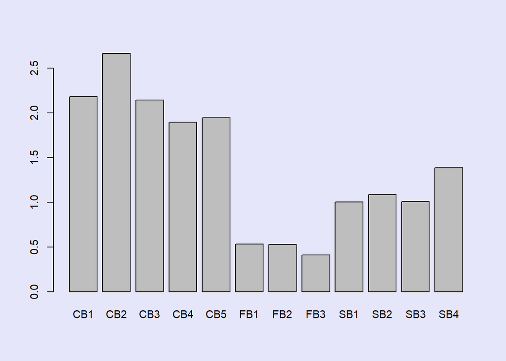

```r
BankData2 %$% tapply(CLPD,bank,mean) %>% barplot()
```

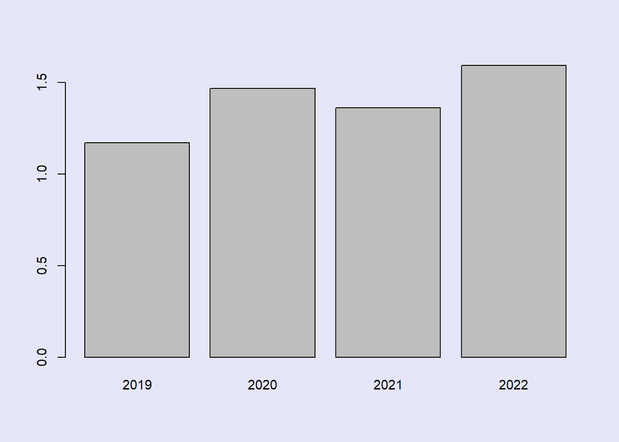

```r
BankData2 %$% tapply(CLPD,year,mean) %>% barplot()
```

please use `BankData1` to get the same results.

[figure not shown]

```r
BankData1 %>%
  group_by(bank) %>%
  summarize(mean_CLPD = mean(PD[loantype == "CL"])) %>%
  ggplot(aes(x = bank, y = mean_CLPD)) +
  geom_bar(stat = "identity") +
  xlab("Bank") +
  ylab("Mean Default Rate for Commercial Loans (%)") +
  ggtitle("Mean Default Rates for Commercial Loans by Bank") +
  theme_classic()
```

[figure not shown]

```r
BankData1 %>%
  group_by(year) %>%
  summarize(mean_CLPD = mean(PD[loantype == "CL"])) %>%
  ggplot(aes(x = year, y = mean_CLPD)) +
  geom_bar(stat = "identity") +
  xlab("Year") +
  ylab("Mean Default Rate for Commercial Loans (%)") +
  ggtitle("Mean Default Rates for Commercial Loans by Year") +
  theme_classic()
```

Given

```r
BankData1 %$% tapply(PD,list(loantype,year),mean) %>% ptable()
```

|  | 2019 | 2020 | 2021 | 2022 |
| --- | --- | --- | --- | --- |
| BL | 4.490533 | 3.966344 | 3.562083 | 4.614649 |
| CL | 1.171663 | 1.467646 | 1.361393 | 1.593602 |

```r
BankData1 %$% tapply(PD,list(year,loantype),mean) %>% ptable()
```

|  | BL | CL |
| --- | --- | --- |
| 2019 | 4.490533 | 1.171663 |
| 2020 | 3.966344 | 1.467646 |
| 2021 | 3.562083 | 1.361393 |
| 2022 | 4.614649 | 1.593602 |

please use `BankData2` to get the same results.

```r
BD2_wide <- BankData2 %$% rbind (tapply(BLPD, year,mean), tapply(CLPD, year,mean))
rownames(BD2_wide) <- c("BL", "CL")

BD2_wide %>% ptable()
```

|  | 2019 | 2020 | 2021 | 2022 |
| --- | --- | --- | --- | --- |
| BL | 4.490533 | 3.966344 | 3.562083 | 4.614649 |
| CL | 1.171663 | 1.467646 | 1.361393 | 1.593602 |

```r
t(BD2_wide) %>% ptable()
```

|  | BL | CL |
| --- | --- | --- |
| 2019 | 4.490533 | 1.171663 |
| 2020 | 3.966344 | 1.467646 |
| 2021 | 3.562083 | 1.361393 |
| 2022 | 4.614649 | 1.593602 |